# The Writing Process: Getting Started

## Once upon a time…

- **You want to craft a clear, compelling story and tailor your capstone to the intended audience.**
- **You can’t assume that your reader will understand why you have chosen to write about a particular topic or why they should care about it**
- **An important aspect of your capstone paper will be to convey why what you are writing about is important**
  - what do we know about the topic?
  - what do we NOT know about the topic?
  - why is this information important?
  - what message do I want readers to take away?

[figure not shown]

## Structure of a scientific paper

**All three capstone types will follow the same general structure**

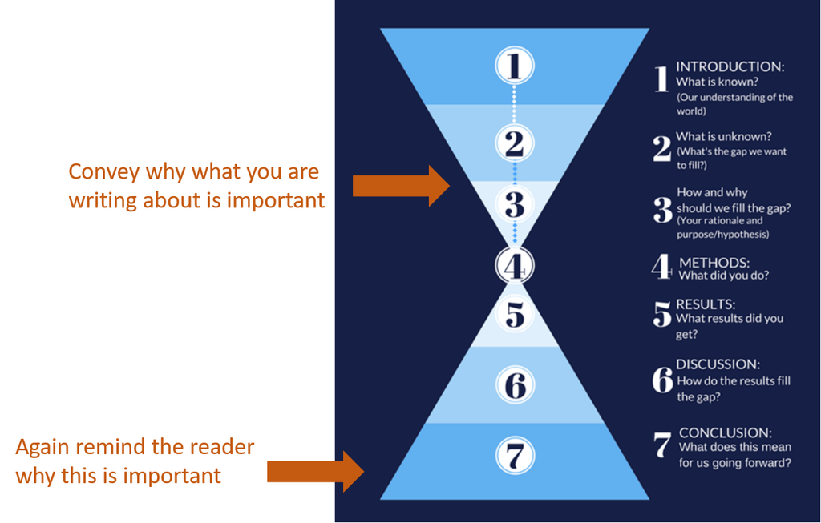

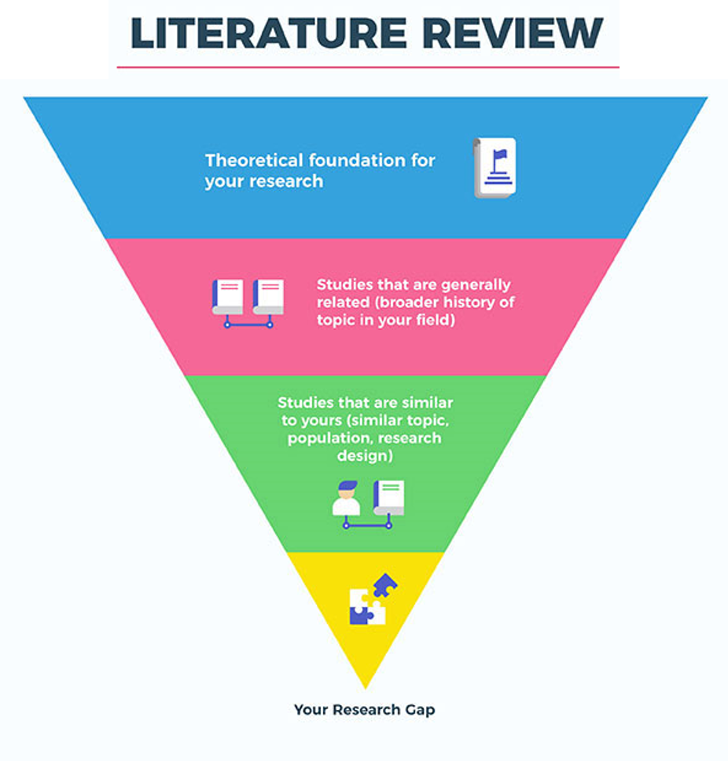

## Build your capstone reference database

- **Use PubMed, Google Scholar, and Web of Science to collect references in Mendeley**
  - even if you do not have the full text yet
  - Request full texts from inter-library loan
  - Dr. C can also help (a little)
- **On Google Scholar, search the papers that have cited a paper you have found**
  - use ‘Cited by #’ and ‘Related articles’ options
  - https://scholar.google.com/
  - go down the rabbit hole!
- **Read and summarize papers on a set schedule**
  - extract information that will be useful in your paper
  - organize into the appropriate section
    - Introduction, Discussion, sub-section

[figure not shown]

## Getting started…

**…is the hardest part. So take small steps!**

- **You don’t need to have everything in hand before beginning**
  - you can always go back and add to your text
- **Assemble your notes, papers, and ideas together in one place**
  - create a detailed outline
- **Dr. C likes to build one paragraph at time**
  - organizing papers, opening statements, actual writing

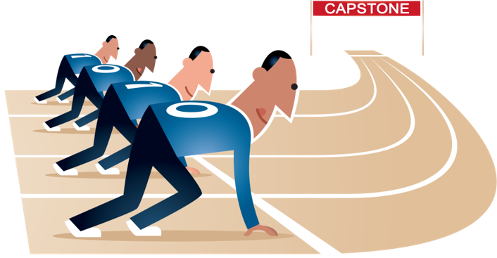

## Brainstorming…

- **Jot down ideas, important bits of research, and any outstanding questions. You can always eliminate later.**
  - create a mind map
  - start a document with main ideas
  - free write as ideas come to you
- **Write a working title for your paper**
  - Establishes your roadmap
  - Keeps you focused

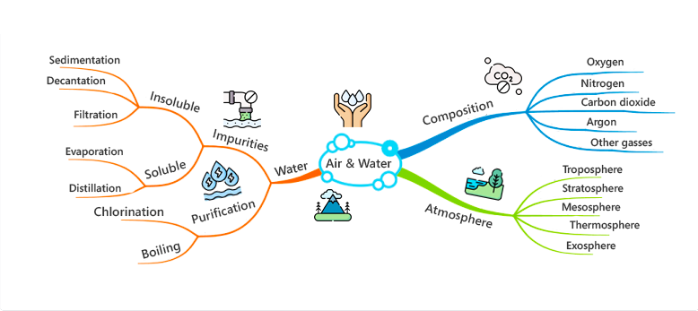

## Putting together an outline is key

- **The goal of an outline is to organize your many ideas (eventually into a coherent story)**
- **Your first outline can be broad—don’t worry about writing complete sentences/paragraphs**
  - group cite-able articles into appropriate sections (First outline)
  - extract information from those articles (Final outline)
- **Do not try to achieve perfection!**
- **CAPSTONE BENCHMARK: Outline due September 17<sup>th</sup>**

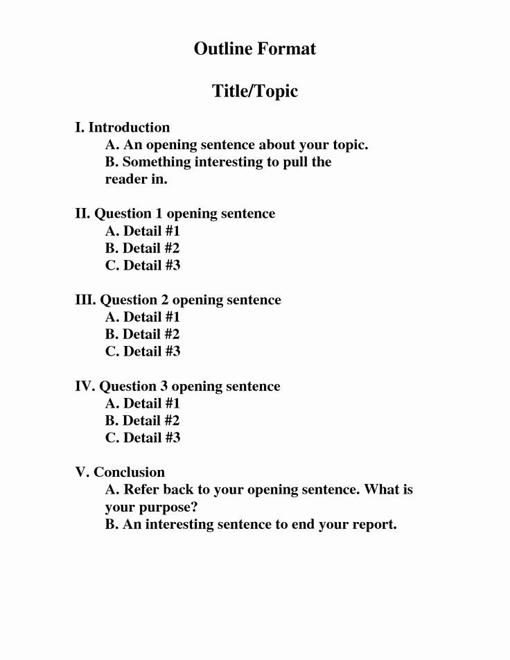

## Organizing your ideas will keep you focused

- **Review your brainstorming notes and place related ideas in the same group**
  - use highlighters to mark up your mind map or written notes
  - sort your index cards
  - have a blank piece of paper for each grouping and rewrite your notes on them
  - or adapt an online version of above
- **Each of these groups will form a main point (or perhaps a subsection of the paper)**
  - add a section to your outline
  - develop ‘stories’ that will be written as paragraphs

[figure not shown]

## Group your information…

- **Broad ideas correspond to main points**
- **Specific details are supporting pieces of information**
- **Use the main points to create your subheadings and/or paragraphs within different sections of the paper (Introduction, Discussion, etc.)**
- **Order the subheadings and paragraphs according to the overall structure of your paper**
  - keep in mind the inverted pyramid
  - keep in mind a persuasive ‘flow’ of ideas

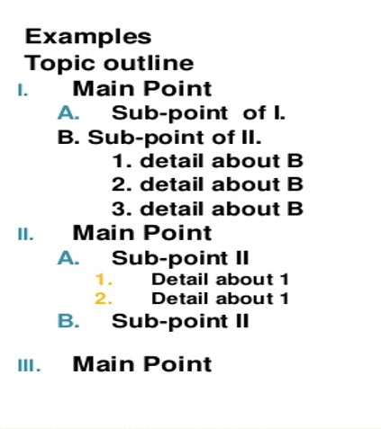

## Moving from outline to draft…

- **Each paragraph will be based on a main point in your outline:**
  - The main point will form the topic sentence of a paragraph
  - Details that support or elaborate upon the main point make up the rest of the sentences
- **Try to write in paragraph chunks**
  - compare and contrast findings from published sources
  - group ‘like’ information into single statements with multiple citations
  - take your time to synthesize the ‘story’
- **We will utilize a 2<sup>nd</sup> detailed outline, then a draft**

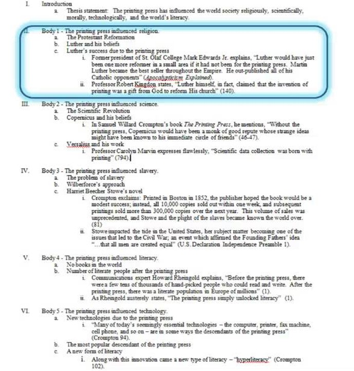

## Paragraphs have structure and tell a story

**Topic sentence: Key topic in the paragraph**  
**Development: Develop your topic in more detail**  
**Support: Provide evidence or data that show your development is valid**  
**Summary and Transition: Summarize the main point, transition to next paragraph**

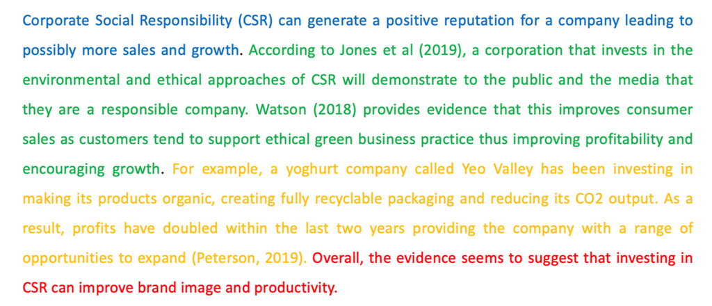

## Working on your first draft

- **If you get stuck, talk to someone about what you are writing (me)—this can lead you to new ways of saying things**
- **Don’t worry about length. If you have an appropriate amount of ideas and supporting material, your paper will be the correct length.**
  - the more citations you have, the easier it is to write!
- **Again, don’t strive for perfection as you write. There will be time to go back afterward and revise**
  - keeping writing momentum is key

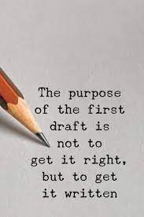

## The first draft: an author’s perspective

**Writing is a process, and very rarely (if ever) will you produce your best work on your first try!**

“Get it down. Take chances. It may be bad, but its the only way you can do anything really good.” — William Faulkner  
“I’m writing a first draft and reminding myself that I’m simply shoveling sand into a box, so that later, I can build castles.” — Shannon Hale

[figure not shown]

## Revise! Revise! Revise!

- **It can’t be overstated how important revision is to writing!**
- **Revision is the step focused on improving the readability and professionalism of your paper**
- **Revise with a purpose!**
  - check for specific errors each time (grammar, tense, figures)
  - just re-reading will not work

* **What should you evaluate when revising your outline?**

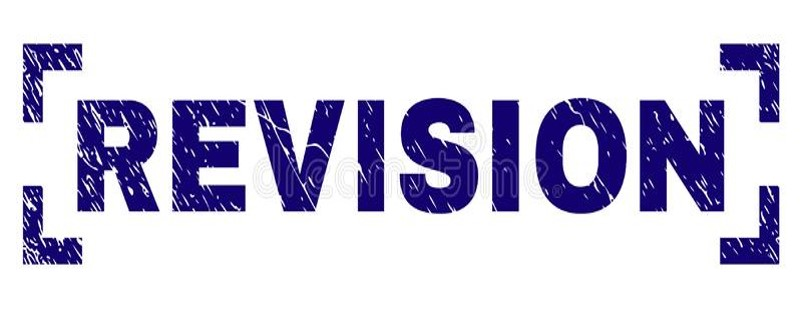